# Functions

## Writing your own functions

So far we’ve seen many functions, like `c()`, `class()`, `filter()`, `dim()` …

**Why create your own functions?**

- Cut down on repetitive code (easier to fix things!)
- Organize code into manageable chunks
- Avoid running code unintentionally
- Use names that make sense to you

## Writing your own functions

The general syntax for a function is:

```
my_function <- function(argument) {
 <function body>
}
```

OR

```
my_function <- \(argument) {
 <function body>
}
```

## Writing your own functions

Here we will write a function that divides some number `x` by 100:

```r
div_100 <- function(x) x / 100
```

When you run the line of code above, you make it ready to use (no output yet!).

Let’s test it:

```r
div_100(x = 600)
```

```
[1] 6
```

## Writing your own functions

We can take all kinds of arguments. Here is one with text:

```r
greeting <- function(name) paste("Hello my name is", name)
```

Let’s test it:

```r
greeting(name = "Ava") # Named argument
```

```
[1] "Hello my name is Ava"
```

```r
greeting("Ava") # R guesses argument based on position
```

```
[1] "Hello my name is Ava"
```

## Writing your own functions: `{ }`

Adding the curly braces - `{}` - allows you to use functions spanning multiple lines:

```r
div_100 <- function(x) {
  x / 100
}
div_100(x = 10)
```

```
[1] 0.1
```

## Writing your own functions: `return`

If we want something specific for the function’s output, we use `return()`:

```r
div_100_plus_4 <- function(x) {
  output_int <- x / 100
  output <- output_int + 4
  return(output)
}
div_100_plus_4(x = 10)
```

```
[1] 4.1
```

## Writing your own functions: multiple inputs

Functions can take multiple inputs:

```r
div_100_plus_y <- function(x, y) x / 100 + y
div_100_plus_y(x = 10, y = 3)
```

```
[1] 3.1
```

## Writing your own functions: multiple outputs

Functions can return a vector (or other object) with multiple outputs.

```r
x_and_y_plus_2 <- function(x, y) {
  output1 <- x + 2
  output2 <- y + 2

  return(c(output1, output2))
}
result <- x_and_y_plus_2(x = 10, y = 3)
result
```

```
[1] 12  5
```

## Writing your own functions: defaults

Functions can have “default” arguments. This lets us use the function without using an argument later:

```r
div_100_plus_y <- function(x = 10, y = 3) x / 100 + y
div_100_plus_y()
```

```
[1] 3.1
```

```r
div_100_plus_y(x = 11, y = 4)
```

```
[1] 4.11
```

## Writing another simple function

Let’s write a function, `sqdif`, that:

1. takes two numbers `x` and `y` with default values of 2 and 3.
2. takes the difference
3. squares this difference
4. then returns the final value

## Writing another simple function

```r
sqdif <- function(x = 2, y = 3) (x - y)^2

sqdif()
```

```
[1] 1
```

```r
sqdif(x = 10, y = 5)
```

```
[1] 25
```

```r
sqdif(10, 5)
```

```
[1] 25
```

```r
sqdif(11, 4)
```

```
[1] 49
```

## Writing your own functions: characters

Again, functions can have any kind of input.

```r
loud <- function(word = "hooray!") {
  output <- rep(toupper(word), 5)
  return(output)
}
```

```r
loud()
```

```
[1] "HOORAY!" "HOORAY!" "HOORAY!" "HOORAY!" "HOORAY!"
```

```r
loud("wow!")
```

```
[1] "WOW!" "WOW!" "WOW!" "WOW!" "WOW!"
```

## Functions for tibbles - Example with ggplot

```r
er <- read_csv(file = "https://daseh.org/data/CO_ER_heat_visits.csv")

visits_plot <- function(the_county){
   er_sub <- er |> filter(county == the_county)
   ggplot(data = er_sub, aes(x = year, y = visits)) +
     geom_point()
 }
```

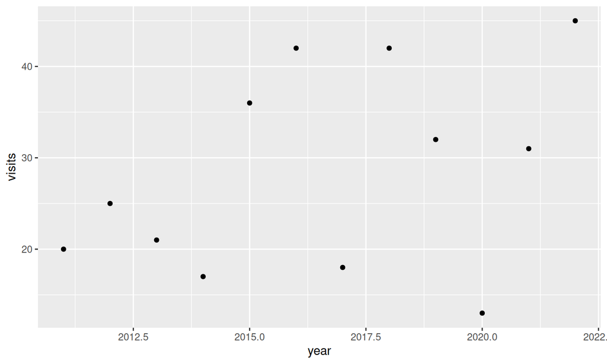

```r
visits_plot("Larimer")
```

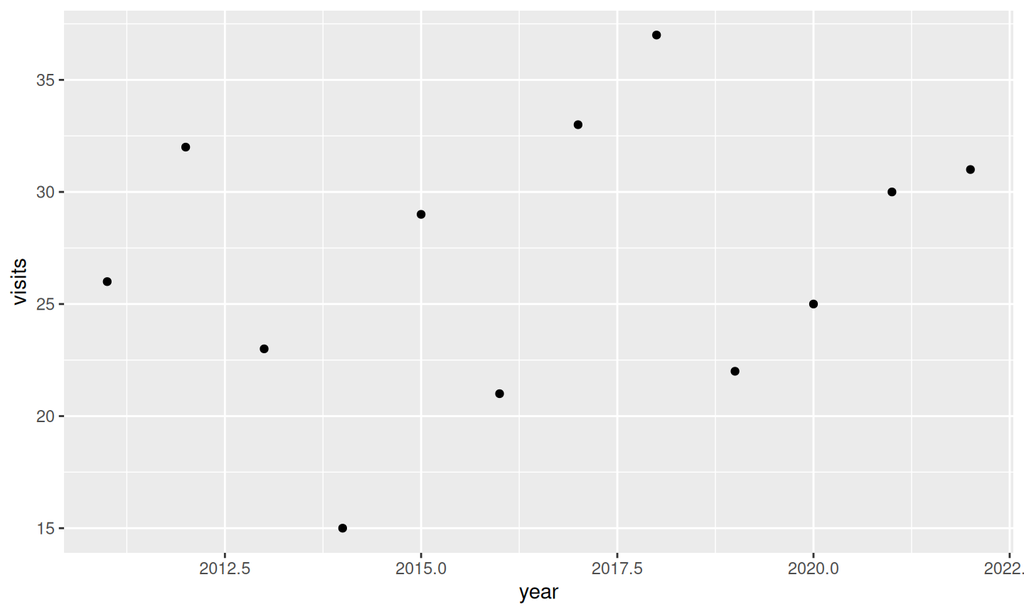

```r
visits_plot("Weld")
```

## Functions for tibbles - curly braces

```r
visits_plot2 <- function(the_column){
   ggplot(data = er, aes(x = year, y = visits, color = {{the_column}})) +
     geom_point()
 }
```

## Functions for tibbles - example

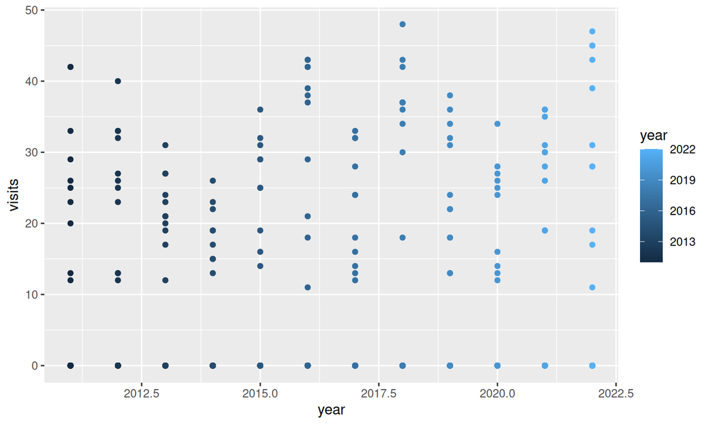

```r
visits_plot2(year)
```

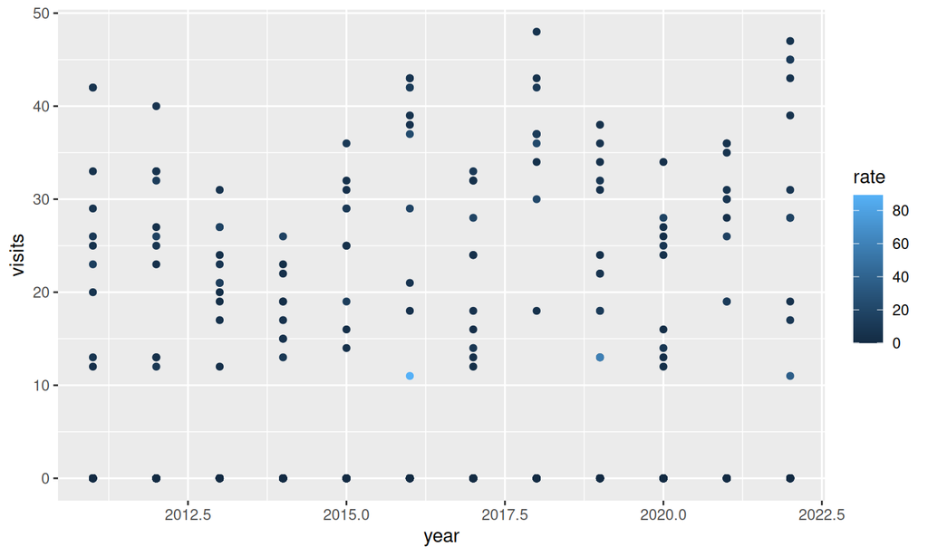

```r
visits_plot2(rate)
```

## Summary

- Simple functions take the form:
  - `NEW_FUNCTION <- function(x, y){x + y}`
  - Can specify defaults like `function(x = 1, y = 2){x + y}`
  - `return` will provide a value as output
- Specify a column (from a tibble) inside a function using `{{double curly braces}}`

## Lab Part 1

🏠 [Class Website](https://daseh.org/)

💻 [Lab](https://daseh.org/modules/Functions/lab/Functions_Lab.Rmd)

## Functions on multiple columns

## Using your custom functions: `sapply()`- a base R function

Now that you’ve made a function… You can “apply” functions easily with `sapply()`!

These functions take the form:

```
sapply(<a vector, list, data frame>, some_function)
```

## Using your custom functions: `sapply()`

Let’s apply a function to look at the CO heat-related ER visits dataset.

🚨There are no parentheses on the functions!🚨

You can also pipe into your function.

```r
sapply(er, class)
```

```
     county        rate   lower95cl   upper95cl      visits        year
"character"   "numeric"   "numeric"   "numeric"   "numeric"   "numeric"
```

```r
# also: er |> sapply(class)
```

## Using your custom functions: `sapply()`

Use the `div_100` function we created earlier to convert 0-100 percentiles to proportions.

```r
er |>
  select(ends_with("cl")) |>
  sapply(div_100) |>
  head()
```

```
      lower95cl  upper95cl
[1,]         NA 0.09236776
[2,] 0.02848937         NA
[3,] 0.04359735 0.09313561
[4,] 0.01711087 0.04846996
[5,] 0.01892912 0.05232461
[6,] 0.06124961 0.11572046
```

## Using your custom functions “on the fly” to iterate

Also called “anonymous function”.

```r
er |>
  select(ends_with("cl")) |>
  sapply(function(x) x / 100) |>
  head()
```

```
      lower95cl  upper95cl
[1,]         NA 0.09236776
[2,] 0.02848937         NA
[3,] 0.04359735 0.09313561
[4,] 0.01711087 0.04846996
[5,] 0.01892912 0.05232461
[6,] 0.06124961 0.11572046
```

## Anonymous functions: alternative syntax

```r
er |>
  select(ends_with("cl")) |>
  sapply(\(x) x / 100) |>
  head()
```

```
      lower95cl  upper95cl
[1,]         NA 0.09236776
[2,] 0.02848937         NA
[3,] 0.04359735 0.09313561
[4,] 0.01711087 0.04846996
[5,] 0.01892912 0.05232461
[6,] 0.06124961 0.11572046
```

## across

## Using functions in `mutate()` and `summarize()`

Already know how to use functions to modify columns using `mutate()` or calculate summary statistics using `summarize()`.

```r
er |>
  summarize(max_visits = max(visits, na.rm = T),
            max_rate = max(rate, na.rm = T))
```

```
# A tibble: 1 × 2
  max_visits max_rate
       <dbl>    <dbl>
1         48     89.3
```

## Applying functions with `across` from `dplyr`

`across()` makes it easy to apply the same transformation to multiple columns. Usually used with `summarize()` or `mutate()`.

```
summarize(across(<columns>,function))
```

or

```
mutate(across(<columns>,function))
```

- List columns first : `.cols =`
- List function next: `.fns =`
- If there are arguments to a function (e.g., `na.rm = TRUE`), use an anonymous function.

## Applying functions with `across` from `dplyr`

Combining with `summarize()`

```r
er |>
  summarize(across(
    c(visits, rate),
    mean # no parentheses
  ))
```

```
# A tibble: 1 × 2
  visits  rate
   <dbl> <dbl>
1     NA    NA
```

## Applying functions with `across` from `dplyr`

Add anonymous function to include additional arguments (e.g., `na.rm = T`).

```r
er |>
  summarize(across(
    c(visits, rate),
    function(x) mean(x, na.rm = T)
  ))
```

```
# A tibble: 1 × 2
  visits  rate
   <dbl> <dbl>
1   7.19  2.43
```

## Applying functions with `across` from `dplyr`

Can use with other tidyverse functions like `group_by`!

```r
er |>
  group_by(year) |>
  summarize(across(
    c(visits, rate),
    function(x) mean(x, na.rm = T)
  ))
```

```
# A tibble: 12 × 3
    year visits  rate
   <dbl>  <dbl> <dbl>
 1  2011   5.20  1.49
 2  2012   5.89  1.75
 3  2013   5.63  1.83
 4  2014   4.12  1.41
 5  2015   6.4   1.96
 6  2016  10.1   5.28
 7  2017   7.24  2.13
 8  2018  11.7   3.28
 9  2019   9.12  4.09
10  2020   6.26  1.73
11  2021   8.06  2.08
12  2022   9.29  3.21
```

## Applying functions with `across` from `dplyr`

Using different `tidyselect()` options (e.g., `starts_with()`, `ends_with()`, `contains()`)

```r
er |>
  group_by(year) |>
  summarize(across(
    contains("cl"),
    function(x) mean(x, na.rm = TRUE)
  ))
```

```
# A tibble: 12 × 3
    year lower95cl upper95cl
   <dbl>     <dbl>     <dbl>
 1  2011     0.836      2.12
 2  2012     1.06       2.41
 3  2013     1.07       2.62
 4  2014     0.810      2.11
 5  2015     1.21       2.77
 6  2016     3.05       7.99
 7  2017     1.28       3.08
 8  2018     2.17       4.41
 9  2019     2.32       6.21
10  2020     1.02       2.52
11  2021     1.30       2.92
12  2022     1.93       4.71
```

## Applying functions with `across` from `dplyr`

Combining with `mutate()` - the `replace_na` function

Let’s look at the yearly CO2 emissions dataset.

```r
yearly_co2 <-
  read_csv(file = "https://daseh.org/data/Yearly_CO2_Emissions_1000_tonnes.csv")

yearly_co2 |>
  select(country, starts_with("194")) |>
  mutate(across(
    c(`1943`, `1944`, `1945`),
    function(x) replace_na(x, replace = 0)
  ))
```

```
# A tibble: 192 × 11
   country        `1940` `1941` `1942` `1943` `1944` `1945` `1946` `1947` `1948`
   <chr>           <dbl>  <dbl>  <dbl>  <dbl>  <dbl>  <dbl>  <dbl>  <dbl>  <dbl>
 1 Afghanistan        NA     NA     NA      0      0      0     NA     NA     NA
 2 Albania           693    627    744    462    154    121    484    928    704
 3 Algeria           238    312    499    469    499    616    763    744    803
 4 Andorra            NA     NA     NA      0      0      0     NA     NA     NA
 5 Angola             NA     NA     NA      0      0      0     NA     NA     NA
 6 Antigua and B…     NA     NA     NA      0      0      0     NA     NA     NA
 7 Argentina       15900  14000  13500  14100  14000  13700  13700  14500  17400
 8 Armenia           848    745    513    655    613    649    730    878    935
 9 Australia       29100  34600  36500  35000  34200  32700  35500  38000  38500
10 Austria          7350   7980   8560   9620   9400   4570  12800  17600  24500
# ℹ 182 more rows
# ℹ 1 more variable: `1949` <dbl>
```

## GUT CHECK!

Why use `across()`?

A. Efficiency - faster and less repetitive

B. Calculate the cross product

C. Connect across datasets

## `purrr` package

Similar to across, `purrr` is a package that allows you to apply a function to multiple columns in a data frame or multiple data objects in a list.

While we won’t get into `purrr` too much in this class, it’s part of the tidyverse and is great if you’re doing lots of iterative work!

## One cool function: `modify_if()`

Columns must meet a certain criteria to be modified.

```r
er |>
  modify_if(is.numeric, \(x) round(x)) |>
  glimpse()
```

```
Rows: 768
Columns: 6
$ county    <chr> "Adams", "Adams", "Adams", "Adams", "Adams", "Adams", "Adams…
$ rate      <dbl> 7, 5, 7, 3, 3, 9, 7, 7, 7, 5, 7, 8, 0, 0, NA, 0, NA, NA, NA,…
$ lower95cl <dbl> NA, 3, 4, 2, 2, 6, 4, 5, 5, 3, 5, 6, 0, 0, NA, 0, NA, NA, NA…
$ upper95cl <dbl> 9, NA, 9, 5, 5, 12, 9, 9, 9, 7, 9, 11, 0, 0, NA, 0, NA, NA, …
$ visits    <dbl> 29, 23, 31, 15, 16, 42, 32, 37, 36, 24, 35, 45, 0, 0, NA, 0,…
$ year      <dbl> 2011, 2012, 2013, 2014, 2015, 2016, 2017, 2018, 2019, 2020, …
```

## Summary

- Apply your functions with `sapply(<a vector or list>, some_function)`
- Use `across()` to apply functions across multiple columns of data
- Need to use `across` within `summarize()` or `mutate()`
- Check out `purrr` if you want to get into the weeds!

## Lab Part 2

🏠 [Class Website](https://daseh.org/)

💻 [Lab](https://daseh.org/modules/Functions/lab/Functions_Lab.Rmd)

📃 [Day 9 Cheatsheet](https://daseh.org/modules/cheatsheets/Day-9.pdf)

📃 [Posit’s `purrr` Cheatsheet](https://rstudio.github.io/cheatsheets/purrr.pdf)

## Research Survey

https://forms.gle/5ac2WPiR9kJu5D3c6

Image by [Gerd Altmann](https://pixabay.com/users/geralt-9301/?utm_source=link-attribution&utm_medium=referral&utm_campaign=image&utm_content=812226) from [Pixabay](https://pixabay.com//?utm_source=link-attribution&utm_medium=referral&utm_campaign=image&utm_content=812226)